# Practical Machine Leanring - Final

David Cooper

April 1, 2017

# Introduction

Using devices such as Jawbone Up, Nike FuelBand, and Fitbit it is now possible to collect a large amount of data about personal activity relatively inexpensively. These type of devices are part of the quantified self movement – a group of enthusiasts who take measurements about themselves regularly to improve their health, to find patterns in their behavior, or because they are tech geeks. One thing that people regularly do is quantify how much of a particular activity they do, but they rarely quantify how well they do it. In this project, your goal will be to use data from accelerometers on the belt, forearm, arm, and dumbell of 6 participants. They were asked to perform barbell lifts correctly and incorrectly in 5 different ways.

# Preparation

The training data for this project are available here:  
https://d396qusza40orc.cloudfront.net/predmachlearn/pml-training.csv

The test data are available here:  
https://d396qusza40orc.cloudfront.net/predmachlearn/pml-testing.csv

The data for this project come from this source: http://groupware.les.inf.puc-rio.br/har.

```r
library(caret) # Loading in the caret library

# Importing the data sets
set_train <- read.csv("data/pml-training.csv")
set_test <- read.csv("data/pml-testing.csv")

# Splitting the training set for cross validation
set.seed(123)
train_split <- createDataPartition(y = set_train$classe, p = 0.7, list = FALSE)
set_train1 <- set_train[train_split, ]
set_train2 <- set_train[-train_split, ]
```

### Reducing the dataset

In order to make model building and prediction faster, we should reduce the dataset to the smallest possible size. We can do this by only accounting for the variables that we are interested in predicting. We can also exclude data that does not vary by much, and so would not be helpful in making any predictions.

```r
# Removing variables that are predominately full of NA values
majority_NA <- sapply(set_train1, function(x) mean(is.na(x))) > 0.95
set_train1 <- set_train1[, majority_NA == FALSE]
set_train2 <- set_train2[, majority_NA == FALSE]

# Removing unneccesary variables for prediction:
# (X, user_name, raw_timestamp_part_1, raw_timestamp_part_2, cvtd_timestamp)
set_train1 <- set_train1[, -(1:5)]
set_train2 <- set_train2[, -(1:5)]

# Excluding variables with near zero variance
zero_var <- nearZeroVar(set_train1)
set_train1 <- set_train1[, -zero_var]
set_train2 <- set_train2[, -zero_var]
```

# Model Building

Let’s begin with a more visual approach, the *Decision Tree Method* .

```r
library(rattle) # Importing the Rattle library
library(rpart)

set.seed(123)
model_dt <- train(classe~., method = "rpart", data = set_train1)

# Printing the final model
print(model_dt$finalModel)
```

```
## n= 13737
##
## node), split, n, loss, yval, (yprob)
##       * denotes terminal node
##
##  1) root 13737 9831 A (0.28 0.19 0.17 0.16 0.18)
##    2) roll_belt< 130.5 12580 8681 A (0.31 0.21 0.19 0.18 0.11)
##      4) pitch_forearm< -26.45 1238   45 A (0.96 0.036 0 0 0) *
##      5) pitch_forearm>=-26.45 11342 8636 A (0.24 0.23 0.21 0.2 0.12)
##       10) num_window>=45.5 10834 8128 A (0.25 0.24 0.22 0.2 0.089)
##         20) num_window< 241.5 2493 1189 A (0.52 0.12 0.11 0.19 0.053) *
##         21) num_window>=241.5 8341 6038 B (0.17 0.28 0.25 0.2 0.1)
##           42) magnet_dumbbell_z< -23.5 2310 1256 A (0.46 0.35 0.05 0.13 0.013)
##             84) num_window< 686.5 1101  237 A (0.78 0.16 0.0036 0.041 0.0091) *
##             85) num_window>=686.5 1209  575 B (0.16 0.52 0.092 0.21 0.016) *
##           43) magnet_dumbbell_z>=-23.5 6031 4021 C (0.058 0.25 0.33 0.23 0.13)
##             86) magnet_dumbbell_x< -445.5 4290 2393 C (0.065 0.16 0.44 0.25 0.086) *
##             87) magnet_dumbbell_x>=-445.5 1741  933 B (0.039 0.46 0.065 0.18 0.25) *
##       11) num_window< 45.5 508  102 E (0 0 0 0.2 0.8) *
##    3) roll_belt>=130.5 1157    7 E (0.0061 0 0 0 0.99) *
```

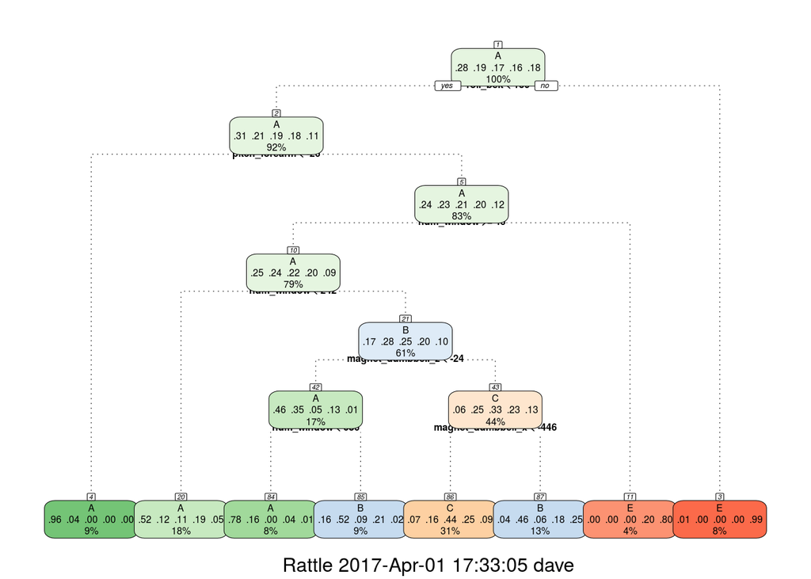

```r
# Visualizing the final model with Rattle
fancyRpartPlot(model_dt$finalModel,cex=.5,under.cex=1,shadow.offset=0)
```

We will next try a model discussed frequently in the course, the *Random Forest* approach.

```r
library(randomForest) # Loading in the Random Forest library

# Setting up, using a cross validation approach
control_fit <- trainControl(method = "cv", number = 2)

# Building the model
model_fit <- train(classe ~. , data = set_train1, method = "rf", trControl = control_fit)

model_fit$finalModel
```

```
##
## Call:
##  randomForest(x = x, y = y, mtry = param$mtry)
##                Type of random forest: classification
##                      Number of trees: 500
## No. of variables tried at each split: 27
##
##         OOB estimate of  error rate: 0.2%
## Confusion matrix:
##      A    B    C    D    E  class.error
## A 3904    1    0    0    1 0.0005120328
## B    6 2650    2    0    0 0.0030097818
## C    0    3 2393    0    0 0.0012520868
## D    0    0   10 2242    0 0.0044404973
## E    0    0    0    5 2520 0.0019801980
```

# Model Evaluation

Now let’s evaluate both of these models to see how well they perform in prediction using our cross validation dataset.

```r
# Testing the Decision Tree Model
set.seed(123)
predict_tree <- predict(model_dt, set_train2)
cross_tree <- confusionMatrix(predict_tree, set_train2$classe)
cross_tree
```

```
## Confusion Matrix and Statistics
##
##           Reference
## Prediction    A    B    C    D    E
##          A 1450  239  114  221   63
##          B  116  616  104  241  206
##          C  101  284  808  458  165
##          D    0    0    0    0    0
##          E    7    0    0   44  648
##
## Overall Statistics
##
##                Accuracy : 0.5985
##                  95% CI : (0.5858, 0.611)
##     No Information Rate : 0.2845
##     P-Value [Acc > NIR] : < 2.2e-16
##
##                   Kappa : 0.4861
##  Mcnemar's Test P-Value : < 2.2e-16
##
## Statistics by Class:
##
##                      Class: A Class: B Class: C Class: D Class: E
## Sensitivity            0.8662   0.5408   0.7875   0.0000   0.5989
## Specificity            0.8487   0.8595   0.7925   1.0000   0.9894
## Pos Pred Value         0.6948   0.4801   0.4449      NaN   0.9270
## Neg Pred Value         0.9410   0.8864   0.9464   0.8362   0.9163
## Prevalence             0.2845   0.1935   0.1743   0.1638   0.1839
## Detection Rate         0.2464   0.1047   0.1373   0.0000   0.1101
## Detection Prevalence   0.3546   0.2180   0.3086   0.0000   0.1188
## Balanced Accuracy      0.8575   0.7001   0.7900   0.5000   0.7941
```

Looking at these results, we can see that the Decision Tree model we used only gave us a ~60% accurate prediction with a 50% in-sample error rate on our cross-validation set.

Let’s try looking at the Random Forest model to see if it is any better.

```r
# Testing the Random Forest model
predict_forest <- predict(model_fit, set_train2)
cross_forest <- confusionMatrix(predict_forest, set_train2$classe)
cross_forest
```

```
## Confusion Matrix and Statistics
##
##           Reference
## Prediction    A    B    C    D    E
##          A 1674    2    0    0    0
##          B    0 1137    4    0    0
##          C    0    0 1022    2    0
##          D    0    0    0  961    0
##          E    0    0    0    1 1082
##
## Overall Statistics
##
##                Accuracy : 0.9985
##                  95% CI : (0.9971, 0.9993)
##     No Information Rate : 0.2845
##     P-Value [Acc > NIR] : < 2.2e-16
##
##                   Kappa : 0.9981
##  Mcnemar's Test P-Value : NA
##
## Statistics by Class:
##
##                      Class: A Class: B Class: C Class: D Class: E
## Sensitivity            1.0000   0.9982   0.9961   0.9969   1.0000
## Specificity            0.9995   0.9992   0.9996   1.0000   0.9998
## Pos Pred Value         0.9988   0.9965   0.9980   1.0000   0.9991
## Neg Pred Value         1.0000   0.9996   0.9992   0.9994   1.0000
## Prevalence             0.2845   0.1935   0.1743   0.1638   0.1839
## Detection Rate         0.2845   0.1932   0.1737   0.1633   0.1839
## Detection Prevalence   0.2848   0.1939   0.1740   0.1633   0.1840
## Balanced Accuracy      0.9998   0.9987   0.9978   0.9984   0.9999
```

### Testing for Out-of-Sample Error

So it appears from our accuracy and in-sample error rate (1-Kappa), we have pretty good model. However, that could be a sign that we have overfitted it. Let’s look at the out-of-sample error rate just to check.

```r
# Calculate the out-of-sample error
OSE <- sum(predict_forest == set_train2$classe)/length(predict_forest)

# Set out-of-sample error rate as a percentage
OSE <- round(((1 - OSE)*100), digits = 2)
```

The out-of-sample error rate for this model is 0.15%, which is good because it shows we still have some wiggle room in our model. So after all this, it looks like the *Random Forest* Model **will** be the one we will use going forward.

# Model Retraining

```r
# Removing variables that are predominately full of NA values
majority_NA <- sapply(set_train, function(x) mean(is.na(x))) > 0.95
set_train <- set_train[, majority_NA == FALSE]

# Removing unneccesary variables for prediction:
# (X, user_name, raw_timestamp_part_1, raw_timestamp_part_2, cvtd_timestamp)
set_train <- set_train[, -(1:5)]

# Excluding variables with near zero variance
zero_var <- nearZeroVar(set_train)
set_train <- set_train[, -zero_var]
```

Now let’s refit the *Random Forest* model using the entire training data set.

```r
# Building the final model
final_fit <- train(classe ~. , data = set_train, method = "rf", trControl = control_fit)
```

# Model Predictions

Let’s apply our model to our test dataset. These final prediction values can be used to answer the Prediction Quiz section of the final project.

```r
final_prediction <- predict(final_fit, set_test)
final_prediction
```

```
##  [1] B A B A A E D B A A B C B A E E A B B B
## Levels: A B C D E
```

# References

Ugulino, W.; Cardador, D.; Vega, K.; Velloso, E.; Milidiu, R.; Fuks, H. [Wearable Computing: Accelerometers’ Data Classification of Body Postures and Movements.](http://groupware.les.inf.puc-rio.br/work.jsf?p1=10335) Proceedings of 21st Brazilian Symposium on Artificial Intelligence. *Advances in Artificial Intelligence - SBIA 2012. In: Lecture Notes in Computer Science.* , pp. 52-61. Curitiba, PR: Springer Berlin / Heidelberg, 2012. ISBN 978-3-642-34458-9. DOI: 10.1007/978-3-642-34459-6_6.

Read more: http://groupware.les.inf.puc-rio.br/har#ixzz4d0yFCAVA